# Titanic Survival Exercise

@uthor: Steven Ponce

Date: 2022-01-21

## Libraries, Options, and Data

```r
# library(tidyverse)
# library(titanic)
# library(tidyquant)

# report 3 significant digits
options(digits = 3)
```

```r
titanic <- titanic_train %>%
  select(Survived, Pclass, Sex, Age, SibSp, Parch, Fare) %>%
  mutate(Survived = factor(Survived),
         Pclass = factor(Pclass),
         Sex = factor(Sex))
```

## Question 1: Variable Types

*Inspect the data and also use `?titanic_train` to learn more about the variables in the dataset. Match these variables from the dataset to their variable type. There is at least one variable of each type (ordinal categorical, non-ordinal categorical, continuous, discrete).*

- Survived: non-ordinal categorical
- Pclass: ordinal categorical
- Sex: non-ordinal categorical
- SibSp: discrete
- Parch: discrete
- Fare: continous

## Question 2: Demographics of Titanic Passengers

*Make density plots of age grouped by sex. Try experimenting with combinations of faceting, alpha blending, stacking and using variable counts on the y-axis to answer the following questions. Some questions may be easier to answer with different versions of the density plot.*

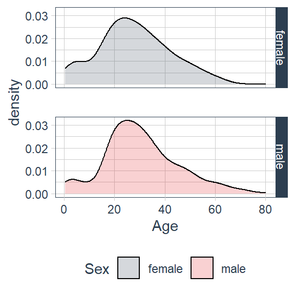

```r
titanic %>%
  ggplot(aes(Age, fill = Sex)) +
  geom_density(alpha = 0.2) +
  facet_grid(Sex ~ .) +
  scale_fill_tq() +
  theme_tq()
```

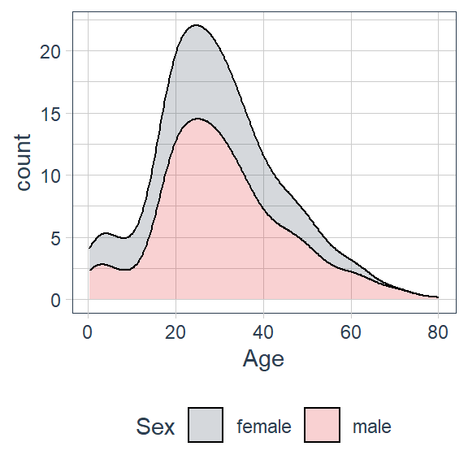

```r
titanic %>%
  ggplot(aes(Age, y = ..count.., fill = Sex)) +
  geom_density(alpha = 0.2, position = "stack")+
  scale_fill_tq() +
  theme_tq()
```

Which of the following are true?

- Females and males had the same general shape of age distribution - **TRUE**

> > *A faceted plot is useful for comparing the distributions of males and females for A. Each sex has the same general shape with two modes at the same locations, though proportions differ slightly across ages and there are more males than females*
- The age distribution was bimodal, with one mode around 25 years of age and a second smaller mode around 5 years of age - **TRUE**
- There were more females than males - FALSE

> > *A stacked density plot with count on the y-axis is useful for answering B, C and D. The main mode is around age 25 and a second smaller mode is around age 4-5. There are more males than females as indicated by a higher total area and higher counts at almost all ages. With count on the y-axis, it is clear that more males than females are age 40.*

```r
gender_count <- titanic %>%
  filter(!is.na(Age)) %>%
  count(Sex)
gender_count
```

```
##      Sex   n
## 1 female 261
## 2   male 453
```

- The count of males of age 40 was higher than the count of females of age 40 - **TRUE**

```r
gender_count_40 <- titanic %>%
  filter(!is.na(Age)) %>%
  filter(Age == 40) %>%
  count(Sex)
gender_count_40
```

```
##      Sex n
## 1 female 6
## 2   male 7
```

- The proportion of males age 18-35 was higher than the proportion of females age 18-35 - **TRUE**

```r
gender_count_18_35 <- titanic %>%
  filter(!is.na(Age)) %>%
  filter(Age >= 18,
         Age <= 35) %>%
  count(Sex)
gender_count_18_35
```

```
##      Sex   n
## 1 female 133
## 2   male 251
```

- The proportion of females under age 17 was higher than the proportion of males under age 17 - **TRUE**

```r
gender_count_under_17 <- titanic %>%
  filter(!is.na(Age)) %>%
  filter(Age < 17) %>%
  count(Sex)
gender_count_under_17
```

```
##      Sex  n
## 1 female 49
## 2   male 51
```

- The oldest passengers were female - FALSE

```r
age_max <- titanic %>%
  filter(!is.na(Age)) %>%
  group_by(Sex) %>%
  summarise(max = max(Age))
age_max
```

```
## # A tibble: 2 x 2
##   Sex      max
##   <fct>  <dbl>
## 1 female    63
## 2 male      80
```

> > *A plot filled by sex with alpha blending helps reveal the answers to E, F and G. There is a higher proportion of females than males below age 17, a higher proportion of males than females for ages 18-35, approximately the same proportion of males and females age 35-55, and a higher proportion of males over age 55. The oldest individuals are male.*

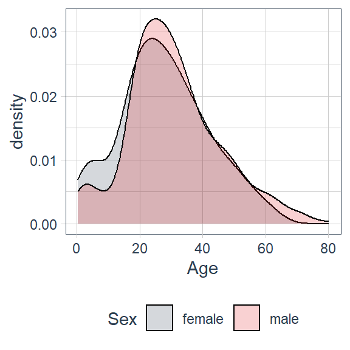

```r
titanic %>%
  ggplot(aes(Age, fill = Sex)) +
  geom_density(alpha = 0.2) +
  scale_fill_tq() +
  theme_tq()
```

## Question 3: QQ-plot of Age Distribution

*Use `geom_qq()` to make a QQ-plot of passenger age and add an identity line with `geom_abline()`. Filter out any individuals with an age of NA first. Use the following object as the `dparams` argument in `geom_qq()`:*

```r
params <- titanic %>%
  filter(!is.na(Age)) %>%
  summarize(mean = mean(Age), sd = sd(Age))
```

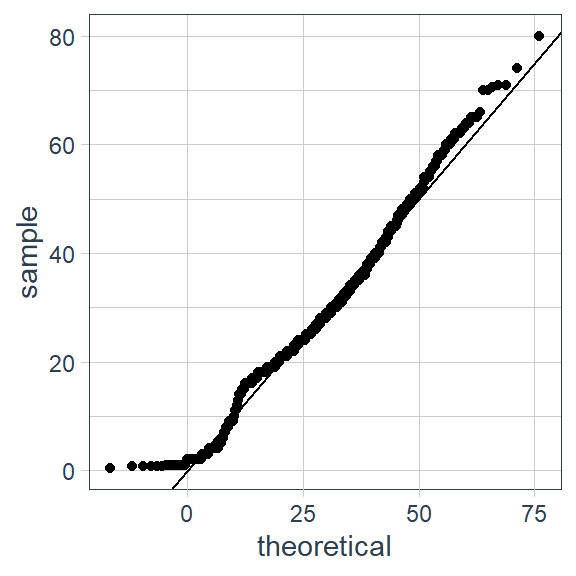

```r
titanic %>%
  ggplot(aes(sample = Age)) +
  geom_qq(dparams = params) +
  geom_abline()+
  scale_fill_tq() +
  theme_tq()
```

## Question 4: Survival by Sex

*To answer the following questions, make barplots of the Survived and Sex variables using `geom_bar()`. Try plotting one variable and filling by the other variable. You may want to try the default plot, then try adding `position = position_dodge()` to `geom_bar()` to make separate bars for each group.*

Which of the following are true?

- Less than half of passengers survived - **TRUE**
- Most of the survivors were female - **TRUE**
- Most of the males survived - FALSE
- Most of the females survived - **TRUE**

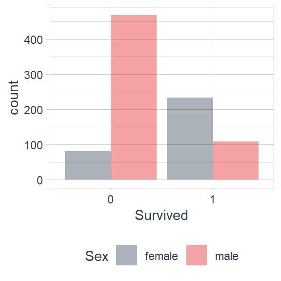

```r
titanic %>%
  ggplot(aes(x = Survived, fill = Sex)) +
  geom_bar(
    position = position_dodge(),
    alpha = .4
    ) +
  scale_fill_tq() +
  theme_tq()
```

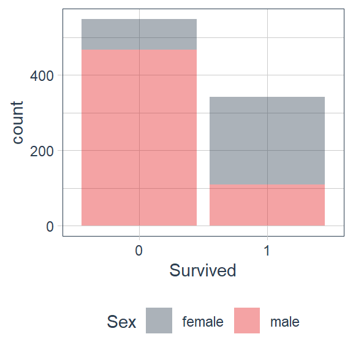

```r
titanic %>%
  ggplot(aes(Survived, fill = Sex)) +
  geom_bar(alpha = .4) +
  scale_fill_tq() +
  theme_tq()
```

## Question 5: Survival by Age

*Make a density plot of age filled by survival status. Change the y-axis to count and set `alpha = 0.2`.*

- Which age group is the only group more likely to survive than die? **0-8**
- Which age group had the most deaths? **18-30**
- Which age group had the highest proportion of deaths? **70-80**

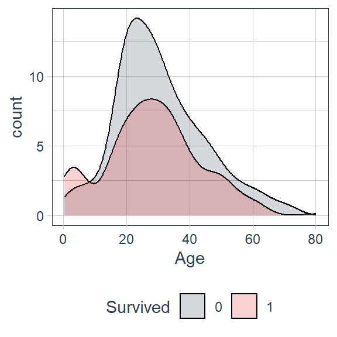

```r
titanic %>%
  ggplot(aes(x = Age, y = ..count.., fill = Survived)) +
  geom_density(alpha = 0.2) +
  scale_fill_tq() +
  theme_tq()
```

## Question 6: Survival by Fare

*Filter the data to remove individuals who paid a fare of 0. Make a boxplot of fare grouped by survival status. Try a log2 transformation of fares. Add the data points with jitter and alpha blending.*

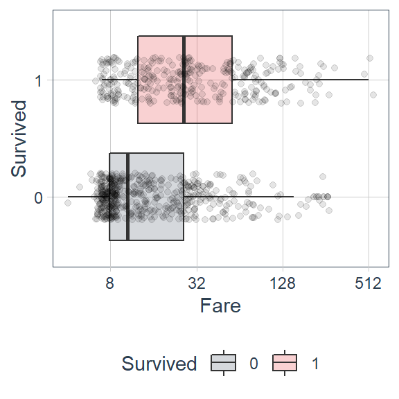

```r
titanic %>%
  filter(Fare != 0) %>%
  ggplot(aes(x = Fare, y = Survived, fill = Survived)) +
  geom_boxplot(alpha = 0.2) +
  scale_x_continuous(trans = 'log2')+
  geom_jitter(
    width = .2, height = 0.2,
    alpha = .1,
    show.legend = FALSE) +
  scale_fill_tq() +
  theme_tq()
```

Which of the following are true?

- Passengers who survived generally payed higher fares than those who did not survive - **TRUE**
- The interquartile range for fares was smaller for passengers who survived - FALSE
- The median fare was lower for passengers who did not survive - **TRUE**
- Only one individual paid a fare around $500. That individual survived - FALSE
- Most individuals who paid a fare around $8 did not survive - **TRUE**

## Question 7: Survival by Passenger Class

*The `Pclass` variable corresponds to the passenger class. Make three barplots. For the first, make a basic barplot of passenger class filled by survival. For the second, make the same barplot but use the argument `position = position_fill()` to show relative proportions in each group instead of counts. For the third, make a barplot of survival filled by passenger class using `position = position_fill()`.*

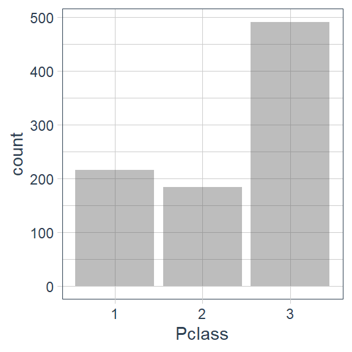

```r
titanic %>%
  ggplot(aes(x = Pclass)) +
  geom_bar(alpha = 0.4) +
  scale_fill_tq() +
  theme_tq()
```

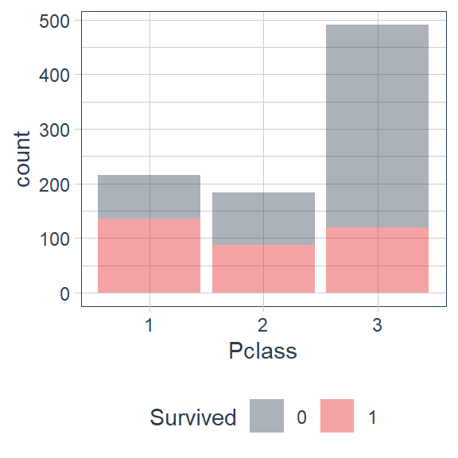

```r
titanic %>%
  ggplot(aes(x = Pclass, fill = Survived)) +
  geom_bar(alpha = 0.4) +
  scale_fill_tq() +
  theme_tq()
```

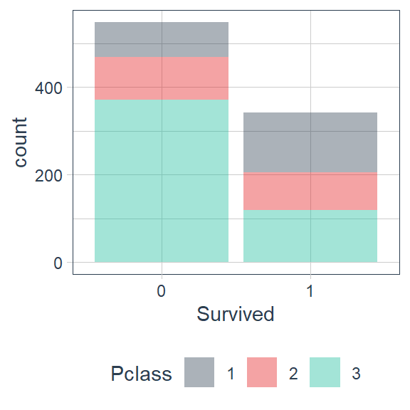

```r
titanic %>%
  ggplot(aes(x = Survived, fill = Pclass)) +
  geom_bar(alpha = 0.4) +
  scale_fill_tq() +
  theme_tq()
```

## Question 8: Survival by Age, Sex and Passenger Class

*Create a grid of density plots for age, filled by survival status, with count on the y-axis, faceted by sex and passenger class.*

Which of the following are true?

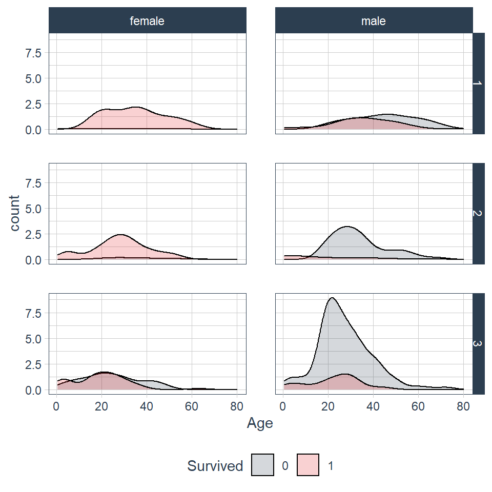

```r
titanic %>%
  ggplot(aes(x = Age, y = ..count.., fill = Survived)) +
  geom_density(alpha = 0.2) +
  facet_grid(Pclass ~ Sex) +
  scale_fill_tq() +
  theme_tq()
```

- The largest group of passengers was third-class males - **TRUE**.
- The age distribution is the same across passenger classes - FALSE.
- The gender distribution is the same across passenger classes - FALSE.
- Most first-class and second-class females survived - **TRUE**.
- Almost all second-class males did not survive, with the exception of children - **TRUE**.